# Application Exercise 05: Merge Conflicts

01.28.19

1. Clone your assignment repo in RStudio Cloud (`ae-05-merge-conflicts-TEAMNAME`), and open the R Markdown file.

2. Assign the numbers 1, 2, 3, and 4 to each of the team members.
   - If you have 3 team members, make one person *Member 2* and *Member 4*.
3. Take turns in completing the steps below exactly as written, only one member at a time:
   - **Member 1**: Change the team name to your team name, knit, commit, push.
   - **Member 2**: Change the team name to something else, knit, commit, push. You will get an error. Pull. Review the document with the merge conflict. Resolve the conflict with the preferred change. Commit and push.
   - **Member 3**: Create a plot displaying the relationship between `price` and `carat`, controlling for `cut` of the diamonds (see below for the plot). Knit, commit, push. You will get an error, read it, and pull. No merge conflicts should occur. Now push.
   - **Member 4**: Create a plot displaying the relationship between `price` and `carat`, controlling for `cut` of the diamonds. Set `alpha = 0.5` in `geom_point()`. Knit, commit, push. You will get an error. Pull. Review the document with the merge conflict. Clear the merge conflict by choosing the correct/preferred change. Commit, and push.
4. **All members:** Pull, and observe the changes in your document.

### Plot for Member 3 to create

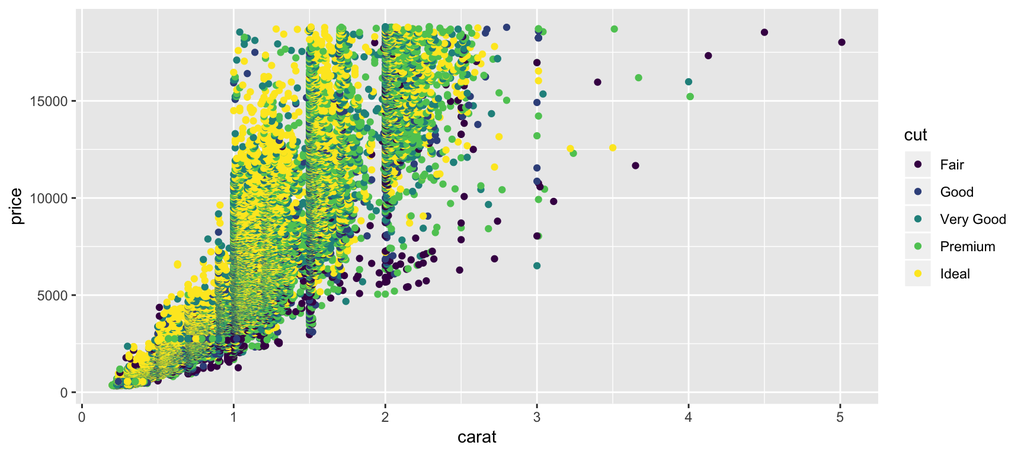